# Multiple Linear Regression

Ranadeep Daw

2024-11-11

## Simple Linear Regression (SLR)

- You learnt simple linear regression:
  - One dependent variable/ response – $y$ .
  - One independent variable/ predictor/ covariate – $x$.
  - $n$ pairs of observations from $x$ and $y$.
  - You built a model:
    $$y_i = \beta_0 + \beta_1 x_i +
    \epsilon_i$$

## Multiple Linear Regression

- Time to extend to multiple linear regression:
  - One dependent variable/ response – $y$ .
  - $p$ independent variables/ predictors/ covariates – $X_1, X_2, \ldots, X_p$.
  - $n$ observations from $\{y$, $X_1, X_2, \ldots, X_p\}$.
  - We will built a similar model:

$$y_i =
\beta_0 + \beta_1 X_{1i} + \beta_2 X_{2i} + \ldots + \beta_p X_{pi} +
\epsilon_i$$

## Model Assumptions

- Similar to SLR, we assume error terms to have a mean $0$ and variance $\sigma^2$, i.e., $\mathbb{E}(\epsilon_i) = 0$; var($\epsilon_i) = \sigma^2$.
- For the error/residual analysis, we will need one additional assumption that $\epsilon_i$-s are normally distributed with ean $0$ and variance $\sigma^2$, i.e., $\epsilon_i \sim \mathbb{N}(0, \sigma^2)$.

## Least square

- Similar to SLR, we try to minimize the total sum of squares:
  $$\sum_{i=1}^n \big[ y_i - (\beta_0 + \beta_1
  X_{1i} + \beta_2 X_{2i} + \ldots + \beta_p
  X_{pi})\big]^2.$$
- We try to find estimates $\widehat{\beta}_0$, $\widehat{\beta}_1$, $\widehat{\beta}_2, \ldots$, $\widehat{\beta}_p$, $\widehat{\sigma}^2$ that minimizes the above.
- Fitted regression equation:

$$\hat{y}_i = \widehat{\beta}_0 +
\widehat{\beta}_1 X_{1i} + \widehat{\beta}_2 X_{2i} + \ldots +
\widehat{\beta}_p X_{pi}$$

## Solutions for estimates

- Unlike SLR, here the expression for $\widehat{\beta}_0, \widehat{\beta}_1, \ldots, \widehat{\beta}_p$ is complicated and needs using matrix forms.
- I will avoid this part. Refer to the textbook to see the formula of estimated coefficient.
- The error variance is estimated by:

$$\widehat{\sigma}^2 = \frac{1}{n - p -
1} \sum_{i=1}^n (y_i - \widehat{y}_i)^2$$

## Our goal

- In this class, we will try to implement this model via $\texttt{R}$ to analyze some data.
- We will use this to build model, check model outputs, and residual analysis.
- You will see some extra concepts such as multicollinearity, variance inflation function (VIF), adjusted $R^2$, and some introduction to nonlinear models.

## $\texttt{R}$ Syntax

- Modeling syntax:

```r
<model_name> = lm(<y_column> ~ <X1_column> + <X2_column> +
                    ... + <Xp_column>, data = <data_name>)
```

- Seeing the summary output:

```r
summary(<model_name>)
```

## Example Data: $\texttt{mtcars}$

- In this lecture, I am going to use the $\texttt{mtcars}$ data from $\texttt{R}$.
- We will use the $\texttt{mpg}$ column (Miles/(US) gallon) as dependent variable ($y$).
- Let’s use $\texttt{disp}$ (Displacement), $\texttt{wt}$, $\texttt{qsec}$, and $\texttt{drat}$ as the independent variables ($X_1$, $X_2$, $X_3$, $X_4$).

## Example

- Remember, to load the $\texttt{mtcars}$ data, we do the following first:

```r
data("mtcars")
```

- Let’s look at the data first.

```r
head(mtcars)
```

```
##                    mpg cyl disp  hp drat    wt  qsec vs am gear carb
## Mazda RX4         21.0   6  160 110 3.90 2.620 16.46  0  1    4    4
## Mazda RX4 Wag     21.0   6  160 110 3.90 2.875 17.02  0  1    4    4
## Datsun 710        22.8   4  108  93 3.85 2.320 18.61  1  1    4    1
## Hornet 4 Drive    21.4   6  258 110 3.08 3.215 19.44  1  0    3    1
## Hornet Sportabout 18.7   8  360 175 3.15 3.440 17.02  0  0    3    2
## Valiant           18.1   6  225 105 2.76 3.460 20.22  1  0    3    1
```

## Plotting

- As long as you have numeric variables, you can write: $\texttt{plot(<dataset_name>)}$ to get pairwise scatterplots.
- Since this would look very messy, you can also try plotting only the significant variables by doing: $\texttt{plot(<dataset_name>[, c("var1", "var2", ...)])}$

## Plotting Example

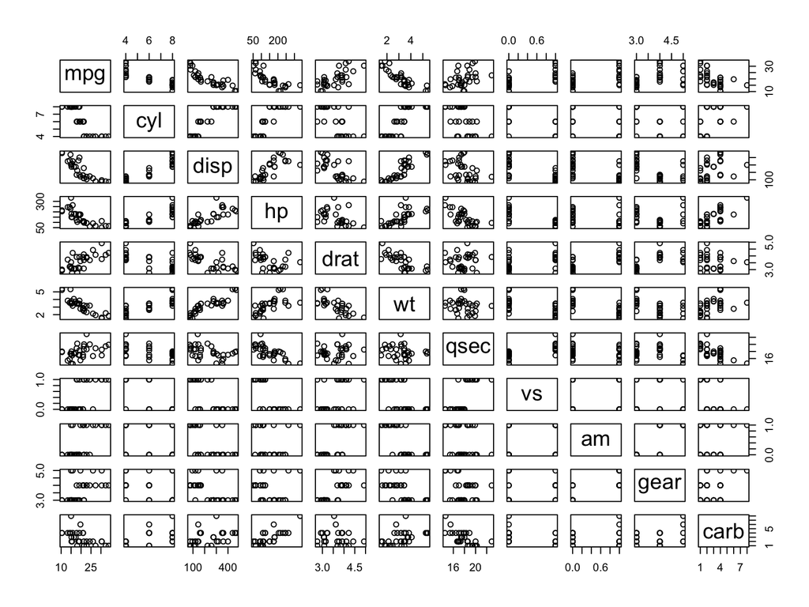

```r
plot(mtcars)
```

## Plotting Example 2

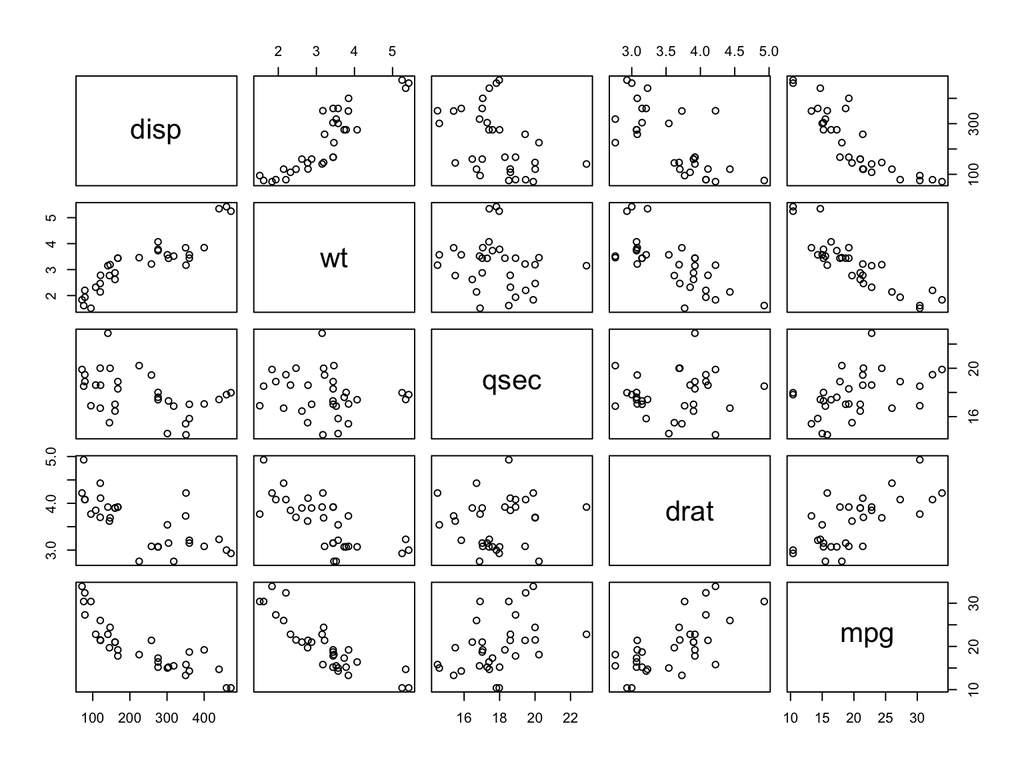

```r
plot(mtcars[c("disp", "wt", "qsec", "drat", "mpg")])
```

## Correlation

- Similar to plotting, you can also do **(with all numeric variables)**:
  - $\texttt{cor(<dataset_name>}$
  - $\texttt{cor(<dataset_name>[, c("var1", "var2", ...)])}$

## Correlation Example

```r
cor(mtcars)
```

```
##             mpg        cyl       disp         hp        drat         wt
## mpg   1.0000000 -0.8521620 -0.8475514 -0.7761684  0.68117191 -0.8676594
## cyl  -0.8521620  1.0000000  0.9020329  0.8324475 -0.69993811  0.7824958
## disp -0.8475514  0.9020329  1.0000000  0.7909486 -0.71021393  0.8879799
## hp   -0.7761684  0.8324475  0.7909486  1.0000000 -0.44875912  0.6587479
## drat  0.6811719 -0.6999381 -0.7102139 -0.4487591  1.00000000 -0.7124406
## wt   -0.8676594  0.7824958  0.8879799  0.6587479 -0.71244065  1.0000000
## qsec  0.4186840 -0.5912421 -0.4336979 -0.7082234  0.09120476 -0.1747159
## vs    0.6640389 -0.8108118 -0.7104159 -0.7230967  0.44027846 -0.5549157
## am    0.5998324 -0.5226070 -0.5912270 -0.2432043  0.71271113 -0.6924953
## gear  0.4802848 -0.4926866 -0.5555692 -0.1257043  0.69961013 -0.5832870
## carb -0.5509251  0.5269883  0.3949769  0.7498125 -0.09078980  0.4276059
##             qsec         vs          am       gear        carb
## mpg   0.41868403  0.6640389  0.59983243  0.4802848 -0.55092507
## cyl  -0.59124207 -0.8108118 -0.52260705 -0.4926866  0.52698829
## disp -0.43369788 -0.7104159 -0.59122704 -0.5555692  0.39497686
## hp   -0.70822339 -0.7230967 -0.24320426 -0.1257043  0.74981247
## drat  0.09120476  0.4402785  0.71271113  0.6996101 -0.09078980
## wt   -0.17471588 -0.5549157 -0.69249526 -0.5832870  0.42760594
## qsec  1.00000000  0.7445354 -0.22986086 -0.2126822 -0.65624923
## vs    0.74453544  1.0000000  0.16834512  0.2060233 -0.56960714
## am   -0.22986086  0.1683451  1.00000000  0.7940588  0.05753435
## gear -0.21268223  0.2060233  0.79405876  1.0000000  0.27407284
## carb -0.65624923 -0.5696071  0.05753435  0.2740728  1.00000000
```

## Correlation Example 2

```r
cor(mtcars[c("disp", "wt", "qsec", "drat", "mpg")])
```

```
##            disp         wt        qsec        drat        mpg
## disp  1.0000000  0.8879799 -0.43369788 -0.71021393 -0.8475514
## wt    0.8879799  1.0000000 -0.17471588 -0.71244065 -0.8676594
## qsec -0.4336979 -0.1747159  1.00000000  0.09120476  0.4186840
## drat -0.7102139 -0.7124406  0.09120476  1.00000000  0.6811719
## mpg  -0.8475514 -0.8676594  0.41868403  0.68117191  1.0000000
```

## Example: Model building

- Now, let’s build the model and see the output:

```r
mlr_model = lm( mpg ~ disp + wt + qsec + drat, data = mtcars )
mlr_model
```

```
##
## Call:
## lm(formula = mpg ~ disp + wt + qsec + drat, data = mtcars)
##
## Coefficients:
## (Intercept)         disp           wt         qsec         drat
##    9.032229     0.005222    -4.867682     1.052478     1.870855
```

## Fitted Model

- **Question**: So what model equation have you got here?
- $$\begin{align*}
  \widehat{y}_i = 9.03 &+ 0.005 X_{1i} + (-4.87) X_{2i} \\
  &+ 1.05 X_{3i} + 1.87 X_{4i}.
  \end{align*}$$

$$\begin{align*}
\widehat{\text{mpg}}_i = 9.03 &+ 0.005 \,\text{disp}_i + (-4.87) \,
\text{wt}_i \\
&+ 1.05 \, \text{qsec}_{i} + 1.87 \, \text{drat}_{i}.
\end{align*}$$

## Interpretation of intercept

- **Question**: How would you interpret $\widehat{\beta}_0$?
  - **Answer**: When all the predictor/ independent variables are set as 0, $\widehat{\beta}_0$ is the predicted mean response $\hat{y}$.
- In the last example, when disp, wt, qsec, and drat are set to $0$, the predicted mpg is $\widehat{\beta}_0$ = 9.03.

## Interpretation of slopes

- **Question**: How would you interpret any other $\widehat{\beta}_j$ (i.e., $\widehat{\beta}_1, \ldots, \widehat{\beta}_p$)?
  - **Answer**: Holding all other variables constant, a 1-unit increase in the $j$-th variable results in a change of $\widehat{\beta}_j$ in the predicted mean response.

## Interpretation of slopes

- For example, in the previous case, with $\texttt{disp}$, $\texttt{drat}$, and $\texttt{wt}$ held constant, increasing qsec (the 3rd variable) by 1 unit would increase the predicted mpg by $\widehat{\beta}_3$ = 1.05.
- Similarly, keeping $\texttt{disp}$, $\texttt{drat}$, and $\texttt{qsec}$ fixed, increasing wt (the 2nd variable) by 1 unit would change the predicted mpg by $\widehat{\beta}_2$ = (-4.87), meaning mpg would decrease by 4.87 units.

## Summary output (You may have to scroll)

```r
summary(mlr_model)
```

```
##
## Call:
## lm(formula = mpg ~ disp + wt + qsec + drat, data = mtcars)
##
## Residuals:
##     Min      1Q  Median      3Q     Max
## -4.1428 -1.9328 -0.1491  0.9191  5.5408
##
## Coefficients:
##              Estimate Std. Error t value Pr(>|t|)
## (Intercept)  9.032229   9.588294   0.942 0.354543
## disp         0.005222   0.011047   0.473 0.640215
## wt          -4.867682   1.208716  -4.027 0.000412 ***
## qsec         1.052478   0.347782   3.026 0.005387 **
## drat         1.870855   1.324623   1.412 0.169265
## ---
## Signif. codes:  0 '***' 0.001 '**' 0.01 '*' 0.05 '.' 0.1 ' ' 1
##
## Residual standard error: 2.596 on 27 degrees of freedom
## Multiple R-squared:  0.8384, Adjusted R-squared:  0.8144
## F-statistic: 35.01 on 4 and 27 DF,  p-value: 2.547e-10
```

## Estimated error variance

- - **Question:** What is the estimated error standard deviation from the output?
  - Same as SLR: see the Residual Standard Error.
  - Here, $\widehat{\sigma} = 2.596.$
- **Question:** What is the estimated error **variance** from the output?
  - You have to square the residual standard error.
  - $\widehat{\sigma}^2 = 2.596^2 = 6.739$

## Interpretation of $R^2$

- Like SLR, $R^2$ is going to be the fraction of the explained variability (SS$_{\text{reg}}$) and the total variability $S_{yy}$. Recall that:

$$\begin{align*}
\sum_{i=1}^n \big(y_i - \bar{y} \big)^2 &= \sum_{i=1}^n
\big(\widehat{y}_i - \bar{y} \big)^2 + \sum_{i=1}^n \big(y_i -
\widehat{y}_i \big)^2 \\
\Rightarrow S_{yy} &= SS_{\text{reg}} + SSE \qquad \text{(error sum
of squares)}
\end{align*}$$

## Finding $R^2$

- **Question:** What is the $R^2$ of the regression model from the output?
  - Look at the Multiple R-squared option in the output.
  - $R^2 = 0.8384$.
- **Question:** How would you interpret the $R^2$?
  - Approximately $83.84\%$ variability of mpg ($y$) is being explained by my model.

## Model significance

- Here is something different from SLR.
- In multiple linear regression, if our model is not meaningful, it suggests that none of the independent variables are contributing to predicting $y$.
- This is equivalent to testing $H_0: \beta_1 = \beta_2 = \ldots = \beta_p = 0$.
- **Careful, $\beta_0$ is never included here**.
- Alternate hypothesis: At least one of the coefficient is not 0.

## Example: Test for $\beta_2 = 0$ (at $\alpha = 0.05$)

- Look at the row for $\beta_2$ and the column *Pr(>|t|)* in the coefficients table.
  - $t$ statistic: **-4.027** (column 3) = $\frac{-4.867682 }{ 1.208716}$. [Note: **Column 3 = $\frac{\text{column 1}}{\text{column 2}}$.**]
  - Since $p$-value (0.00) in column $4$ is less than $\alpha$ (0.05), we reject $H_0$ that $\beta_2 = 0$.
  - This means that the corresponding variable ($\texttt{wt}$) is significant in predicting $\texttt{mpg}$.

## Example: Test for $\beta_1 = 0$ (at $\alpha = 0.05$)

- $t$ statistic: **0.473** (column 3) = $\frac{0.005222 }{ 0.011047}$.
- Since $p$-value (0.64) in column $4$ is greater than $\alpha$ (0.05), we fail to reject $H_0$ that $\beta_1 = 0$.
- This means that the corresponding variable ($\texttt{disp}$) is not significant at level $\alpha = 0.05$ in predicting $\texttt{mpg}$.

## Confidence Intervals

- $\texttt{R}$ syntax: $\texttt{confint(<model_name>, level= <level_value>)}$.
- Example: Find the $95\%$ CI for the parameters of the model you built.

```r
confint(mlr_model, level = 0.95)
```

```
##                   2.5 %      97.5 %
## (Intercept) -10.6413252 28.70578303
## disp         -0.0174449  0.02788933
## wt           -7.3477616 -2.38760152
## qsec          0.3388890  1.76606704
## drat         -0.8470459  4.58875621
```

## Confidence Intervals (Cont.)

- **Question**: From the above $95\%$ CI, can you conclude if $\beta_1$ (coefficient for disp) = 0?
  - **Answer**: Since CI for $\beta_1$ contains 0, we fail to reject the hypothesis that $\beta_1 = 0$.
- **Question**: From the above $95\%$ CI, can you conclude if $\beta_3$ (coefficient for qsec) = 1.5?
  - **Answer**: Since CI for $\beta_3$ contains 1.5, we fail to reject the hypothesis that $\beta_3= 1.5$.

## Influence values

- To plot the influence values using leverage score and Cook’s distance, we will follow the same syntax:

```r
plot(hatvalues(<model_name>), type = 'h') # For Leverage score
plot(cooks.distance(<model_name>), type = 'h') # For Cook's distance
```

## Example: Leverage score

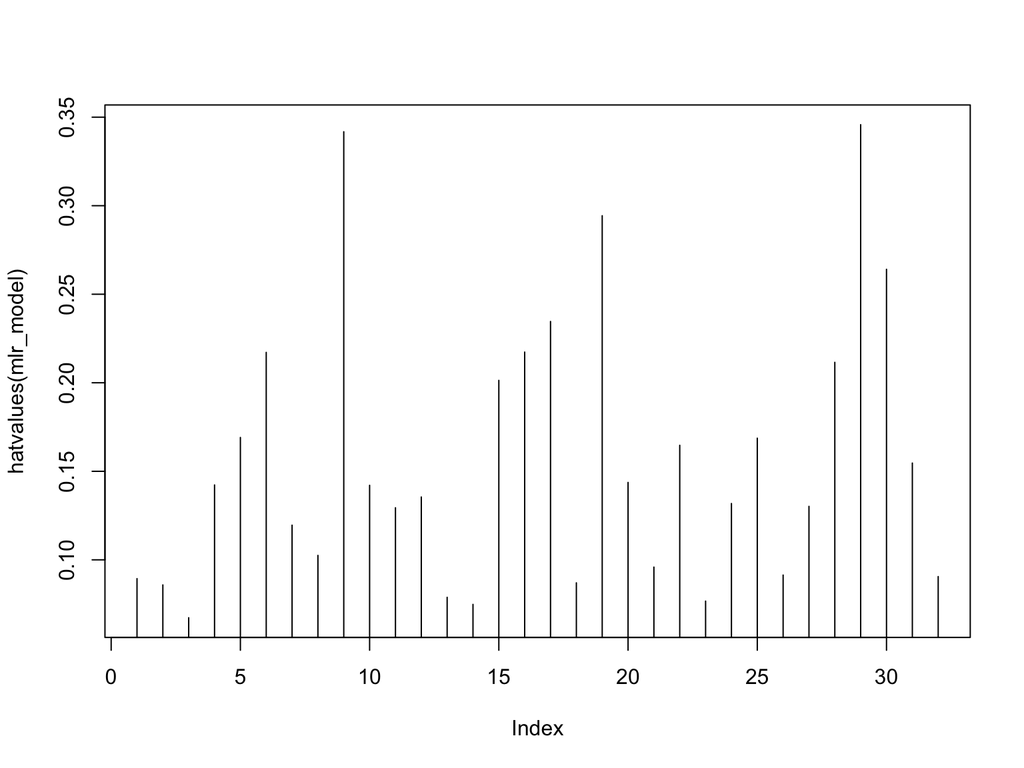

```r
plot(hatvalues(mlr_model), type = 'h')
```

## Example: Cook’s distance

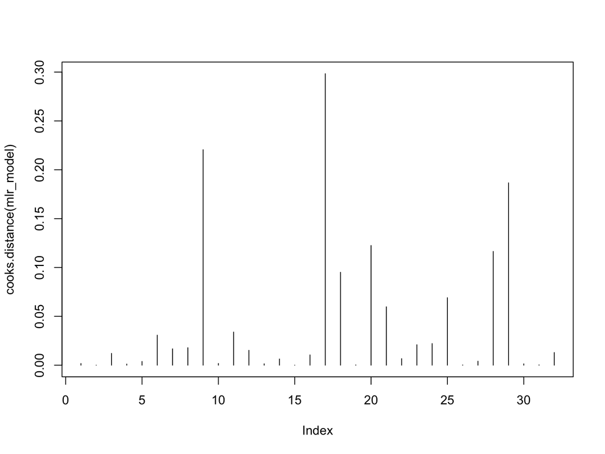

```r
plot(cooks.distance(mlr_model), type = 'h')
```

## Backward Selection

- Let’s look at the coefficients table one more time.

```
##               Estimate Std. Error t value  Pr(>|t|)
## (Intercept)  9.0322289  9.5882939  0.9420 0.3545425
## disp         0.0052222  0.0110473  0.4727 0.6402149
## wt          -4.8676816  1.2087158 -4.0272 0.0004119 ***
## qsec         1.0524780  0.3477817  3.0263 0.0053869 **
## drat         1.8708551  1.3246226  1.4124 0.1692647
## ---
## Signif. codes:  0 '***' 0.001 '**' 0.01 '*' 0.05 '.' 0.1 ' ' 1
```

- See how $\texttt{disp}$ and $\texttt{drat}$ are not significant anymore in predicting $\texttt{mpg}$ (p-value > $\alpha$).
- So, can we create a simplified model?

## Backward Selection

- We can remove the insignificant variables to simplify our model statement.
- You can only remove one variable at a time.
- So, for example, here I will remove $\texttt{disp}$ first and refit my model as:

$$\text{mpg} = \beta_0 + \beta_1 \,
\text{wt}_i + \beta_2 \, \text{qsec}_{i} + \beta_3 \, \text{drat}_{i} +
\epsilon_i$$

- This procedure is called the **backward selection** or **backward elimination** procedure.

## Backward Selection

- **Step 1**: Fit the full model with all predictors.
- **Step 2**: Identify the predictor with the least significance (or the largest p-value). Remove it if its p-value > $\alpha$.
- **Step 3**: Refit the model without this predictor and repeat Step 2.
- **Step 4**: Continue until all remaining predictors are significant (i.e., p value < $\alpha$).

## $\texttt{mtcars}$ Example

- Remove $\texttt{disp}$ and refit the model.

```r
mlr_model2 = lm( mpg ~ wt + qsec + drat, data = mtcars )
summary(mlr_model2)
```

```
##
## Call:
## lm(formula = mpg ~ wt + qsec + drat, data = mtcars)
##
## Residuals:
##     Min      1Q  Median      3Q     Max
## -4.1152 -1.8273 -0.2696  1.0502  5.5010
##
## Coefficients:
##             Estimate Std. Error t value Pr(>|t|)
## (Intercept)  11.3945     8.0689   1.412  0.16892
## wt           -4.3978     0.6781  -6.485 5.01e-07 ***
## qsec          0.9462     0.2616   3.616  0.00116 **
## drat          1.6561     1.2269   1.350  0.18789
## ---
## Signif. codes:  0 '***' 0.001 '**' 0.01 '*' 0.05 '.' 0.1 ' ' 1
##
## Residual standard error: 2.56 on 28 degrees of freedom
## Multiple R-squared:  0.837,  Adjusted R-squared:  0.8196
## F-statistic: 47.93 on 3 and 28 DF,  p-value: 3.723e-11
```

## Example (cont.)

- Still not done. We need to remove $\texttt{drat}$ since this is not significant.

```r
mlr_model3 = lm( mpg ~ wt + qsec , data = mtcars )
summary(mlr_model3)
```

```
##
## Call:
## lm(formula = mpg ~ wt + qsec, data = mtcars)
##
## Residuals:
##     Min      1Q  Median      3Q     Max
## -4.3962 -2.1431 -0.2129  1.4915  5.7486
##
## Coefficients:
##             Estimate Std. Error t value Pr(>|t|)
## (Intercept)  19.7462     5.2521   3.760 0.000765 ***
## wt           -5.0480     0.4840 -10.430 2.52e-11 ***
## qsec          0.9292     0.2650   3.506 0.001500 **
## ---
## Signif. codes:  0 '***' 0.001 '**' 0.01 '*' 0.05 '.' 0.1 ' ' 1
##
## Residual standard error: 2.596 on 29 degrees of freedom
## Multiple R-squared:  0.8264, Adjusted R-squared:  0.8144
## F-statistic: 69.03 on 2 and 29 DF,  p-value: 9.395e-12
```

## Example (cont.)

- See that all the predictor are significant now.
- At $\alpha = 0.05$, this is where we stop and find our simplified model.
- **$\texttt{R}$ implementation:** $\texttt{R}$ automatically can select a model by doing something similar; but with a different stopping criterion.
- Instead of checking parameter significance, $\texttt{R}$ uses a criterion that is called the AIC (Akaike Information Criterion).

## $\texttt{R}$ Automation

- Syntax: $\texttt{step(<full_model>, direction = "backward")}$.
- Continue Example: Fit the initial model first.

```r
mlr_model = lm( mpg ~ disp + wt + qsec + drat, data = mtcars ) # Full model
```

- Do the automated backward selection procedure next.

```r
backward_model = step(mlr_model, direction = "backward")
```

## Continue: See the output

```r
summary(backward_model)
```

```
##
## Call:
## lm(formula = mpg ~ wt + qsec + drat, data = mtcars)
##
## Residuals:
##     Min      1Q  Median      3Q     Max
## -4.1152 -1.8273 -0.2696  1.0502  5.5010
##
## Coefficients:
##             Estimate Std. Error t value Pr(>|t|)
## (Intercept)  11.3945     8.0689   1.412  0.16892
## wt           -4.3978     0.6781  -6.485 5.01e-07 ***
## qsec          0.9462     0.2616   3.616  0.00116 **
## drat          1.6561     1.2269   1.350  0.18789
## ---
## Signif. codes:  0 '***' 0.001 '**' 0.01 '*' 0.05 '.' 0.1 ' ' 1
##
## Residual standard error: 2.56 on 28 degrees of freedom
## Multiple R-squared:  0.837,  Adjusted R-squared:  0.8196
## F-statistic: 47.93 on 3 and 28 DF,  p-value: 3.723e-11
```

## Understanding the difference

- Note that this final model through $\texttt{step}$ is different from the one we have got by comparing significance values.
- This is fine, since the $\texttt{step}$ function in $\texttt{R}$ uses a different stopping criterion (AIC) for model selection.
- We previously used the variable significance checking, i.e., largest $p$-value in the final model should be less than $\alpha$.
- Now, let’s look at one more comparison criterion/tool, which is the Adjusted $R^2$ or $R^2_A$.

## Adjusted $R^2$

- In the last few slides, we have created 3 models.
- Note that, although everytime we tried to improve the model by dropping insignificant variables, the $R^2$ value is going down.
- It is a phenomena that if you add more variables as predictors, however meaningless, $R^2$ always improves.
- Hence, to compare models, we now need to study a different numbers – the adjusted $R^2$ ($R^2_A$).

## Adjusted $R^2$

$$R^2_A = 1 - \frac{(1 -
R^2)(n-1)}{(n-p-1)}$$

- **Properties:**
  - $R^2_A \leq 1$. Higher is better predictive power.
  - Penalizes excessive number of predictors.
  - In a regression model, if you keep adding predictors, $R^2$ always improves; but $R^2_A$ may or may not. Hence, we use it to compare models.
- In the summary table, it is mentioned beside “Adjusted R-squared: $\ldots$”

## Example: continued

- Let’s look at our 3 models and find their adjusted $R^2$.

| Model Name | Predictors | Adjusted R² | R² |
| --- | --- | --- | --- |
| $\texttt{mlr_model}$ | $\texttt{disp, wt, drat, qsec}$ | 0.8144 | 0.8384 |
| $\texttt{mlr_model2}$ | $\texttt{wt, drat, qsec}$ | 0.8196 | 0.837 |
| $\texttt{mlr_model3}$ | $\texttt{wt, qsec}$ | 0.8144 | 0.8264 |

- So, by comparing the $R^2_A$, our second model with $3$ predictor variables seems to be the best.